# **Analysis of Macroeconomic Data for Stock Price Prediction**

*Troy Freed & Ethan Schaferkotter*

https://schaferkotter-freed.github.io/

*Misc. Installs*

```python
import numpy as np
import pandas as pd
import matplotlib.pyplot as plt
import yfinance as yf
import seaborn as sns
```

# Introduction

Stock prices are commonly affected by multiple different macroeconomic factors. This can range from things like unemployment dipping and peaking to the steady climb of the United States' GDP. Thus, predicting the outcome of stocks can be elusive and highly valuable endeavor.

This project in particular aims to leverage historical financial data alongside macroeconomic data in order to potentially create a model for stock price prediction. By integrating these two types of datasets, we seek to understand whether and how macroeconomic trends can affect stock prices over time.

# Project Goals

The goal of this project is to analyze the correlation between the stock market and macroeconomic factors. With this information we plan to create a machine learning model that will be able to predict the stock price of various industries and the market in general based on external market factors.

# Collaboration Plan

Our collaboration plan is to connect once a week at minimum, whether that is in-person or through zoom, in order to make progress on the project. We also plan to communicate consistently through text in order to keep updated on any asynchronous progress we have made. We have set up a shared Google Colab which we will be using as our main venue of editing the project's content, alongside a shared GitHub repository where we both have collaborative access.

# Datasets

We are hoping that by incorporating both of these datasets we will be able to examine the effects certain economic events have on the stock market. By creating a model that can analyze the connections between both of these datasets, we will be able to use past trends of an individual company or industry, and predict whether their stock will go up or down, based on predictions in the economy. We can also use this in the bigger picture, predicting whether the stock market will go into an expansion or recession. For example, being able to predict how much the stock market will drop based on a prediction of a 2% increase in unemployment. We can further use this to even analyze correlation between specific industries, and whether certain industries are more sensitive to things like inflation increases or other factors.

# S&P 500 Data

The following code uses the yfinance libary to extract data relating to the S&P 500. The S&P 500 includes the 500 largest companies on the stock market. Because these companies are from various different industries, it provides a good indicator on how the overall economy is performing. Below, we plotted the closing prices of the S&P 500 from when they started in 1957 to present day. By looking at this graph we can get an idea of the economy over the years, with an example being the drop in the 2008 economic crisis or the sharp decrease in 2020 due to COVID.

One interesting statistic from this is that 50th percentile is actually at a close price of ~360.16, highlighting just how exponential the stock price has grown within the past ~25 years.

```
[*********************100%***********************]  1 of 1 completed
```

```
                                Date  SP500_Close_Price
count                          17117       17117.000000
mean   1991-01-07 17:55:43.833615744         929.801242
min              1957-01-02 00:00:00          38.980000
25%              1974-02-04 00:00:00          98.669998
50%              1991-01-09 00:00:00         360.160004
75%              2007-12-31 00:00:00        1301.349976
max              2024-12-31 00:00:00        6090.270020
std                              NaN        1195.664349


        Date  SP500_Close_Price
0 1957-01-02          46.200001
1 1957-01-03          46.599998
2 1957-01-04          46.660000
3 1957-01-07          46.419998
4 1957-01-08          46.250000
....
            Date  SP500_Close_Price
17112 2024-12-24        6040.040039
17113 2024-12-26        6037.589844
17114 2024-12-27        5970.839844
17115 2024-12-30        5906.939941
17116 2024-12-31        5881.629883
```

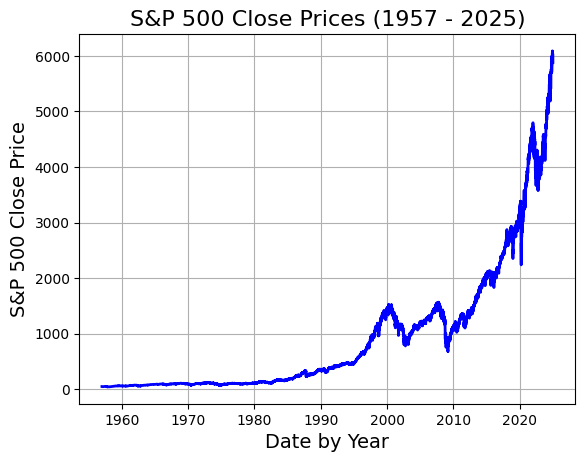

```python
start_date = "1957-01-01"
end_date = "2025-01-01"

# S&P 500 data (GSPC is the ticker (abbreviation) Yahoo Finance uses for the S&P 500)
sp500_data = yf.download("^GSPC", start=start_date, end=end_date)

# Checks if a column consists of a tuple ex: ('Close', 'GSPC')
# and combines it with Close_GSPC
def flatten_col(col):
    return col[0] if col[1] == "" else f"{col[0]}_{col[1]}"

sp500_data.columns = [flatten_col(col) for col in sp500_data.columns.values]

# Reset index to make the date a seperate column instead of the index
sp500_data.reset_index(inplace=True)

# Renames the columns appropriately
tidy_sp500 = sp500_data[['Date', 'Close_^GSPC']].rename(columns={'Close_^GSPC': 'SP500_Close_Price'})

tidy_sp500df = pd.DataFrame(tidy_sp500)
# Making the dataset into a DataFrame to see some general summary statistics
print(tidy_sp500df.describe())
print('\n')


# Grabbing the head and the tail
print(tidy_sp500.head())
print('....')
print(tidy_sp500.tail())

print('\n')

# Create plot of S&P 500 closing prices
plt.plot(tidy_sp500['Date'], tidy_sp500['SP500_Close_Price'], color='blue', linewidth=2)
plt.xlabel('Date by Year', fontsize=14)
plt.ylabel('S&P 500 Close Price', fontsize=14)
plt.title('S&P 500 Close Prices (1957 - 2025)', fontsize=16)
plt.grid(True)
plt.show()
```

# FRED Data

FRED offers United States economic data. This will be used to compare with individual stocks and overall stock market in the future. Currently we have taken in data about the CPI, which is consumer price index and pretty much follows inflation rates. We have also extracted the GDP, which is gross domestic product, and the unemployment rates. By using this data we can find interesting statistics such as how GDP rates have been able to go from 934 to 30000 throughout time. Another interesting statistic is grouping unemployment by decades to see that the 1980's was the period with the highest unemployment rate. We can also find general relationships such as CPI and GDP % tending to rise and drop with each other, showing that inflation comes when the economy is performing well.

```python
#Import CSV files

unemployment = pd.read_csv("https://raw.githubusercontent.com/schaferkotter-freed/schaferkotter-freed.github.io/main/UNRATE.csv")
gdp = pd.read_csv("https://raw.githubusercontent.com/schaferkotter-freed/schaferkotter-freed.github.io/main/GDP.csv")
cpi = pd.read_csv("https://raw.githubusercontent.com/schaferkotter-freed/schaferkotter-freed.github.io/main/CORESTICKM159SFRBATL.csv")


#Tidy variable names

#CPI
cpi = cpi.rename(columns={
    'observation_date': 'Date',
    'CORESTICKM159SFRBATL': 'CPI'
})
#Make pandas know it is a column of dates to make it more interpretable
cpi['Date'] = pd.to_datetime(cpi['Date'])

# GDP
gdp = gdp.rename(columns={
    'observation_date': 'Date',
    'GDP': 'GDP'
})
gdp['Date'] = pd.to_datetime(gdp['Date'])

#Unemployment
unemployment = unemployment.rename(columns={
    'observation_date': 'Date',
    'UNRATE': 'Unemployment_Rate'
})
unemployment['Date'] = pd.to_datetime(unemployment['Date'])


#Merges CPI, GDP, and unemployment rate into 1
merged_df = pd.merge(unemployment, gdp, on='Date', how='inner')
merged_df = pd.merge(merged_df, cpi, on='Date', how='inner')
merged_df.sort_values('Date', inplace=True)

#Find percentage changes between GDP, unemployment rate, and CPI
merged_df['Unemployment_Rate_%'] = merged_df['Unemployment_Rate'].pct_change() * 100
merged_df['GDP_%'] = merged_df['GDP'].pct_change() * 100
merged_df['CPI_%'] = merged_df['CPI'].pct_change() * 100
merged_df = merged_df.dropna()
display(merged_df)
print('\n')

#Stats on GDP
GDP_stats = merged_df['GDP'].describe()
print(GDP_stats)
print('\n')


# Average unemployment rate by decade
merged_df['Year'] = merged_df['Date'].dt.year
merged_df['Decade'] = (merged_df['Year'] // 10) * 10
avg_unemployment_by_decade = merged_df.groupby('Decade')['Unemployment_Rate'].mean()
print(avg_unemployment_by_decade)
```

|  | Date | Unemployment_Rate | GDP | CPI | Unemployment_Rate_% | GDP_% | CPI_% |
| --- | --- | --- | --- | --- | --- | --- | --- |
| 1 | 1968-04-01 | 3.5 | 934.344 | 4.155828 | -5.405405 | 2.744376 | 13.800280 |
| 2 | 1968-07-01 | 3.7 | 950.825 | 4.753076 | 5.714286 | 1.763911 | 14.371341 |
| 3 | 1968-10-01 | 3.4 | 968.030 | 5.182592 | -8.108108 | 1.809481 | 9.036590 |
| 4 | 1969-01-01 | 3.4 | 993.337 | 5.746197 | 0.000000 | 2.614278 | 10.874956 |
| 5 | 1969-04-01 | 3.4 | 1009.020 | 6.505620 | 0.000000 | 1.578820 | 13.216106 |
| ... | ... | ... | ... | ... | ... | ... | ... |
| 223 | 2023-10-01 | 3.9 | 28296.967 | 4.882717 | 11.428571 | 1.177323 | -9.628166 |
| 224 | 2024-01-01 | 3.7 | 28624.069 | 4.601332 | -5.128205 | 1.155961 | -5.762878 |
| 225 | 2024-04-01 | 3.9 | 29016.714 | 4.403618 | 5.405405 | 1.371730 | -4.296886 |
| 226 | 2024-07-01 | 4.2 | 29374.914 | 4.179707 | 7.692308 | 1.234461 | -5.084705 |
| 227 | 2024-10-01 | 4.1 | 29719.647 | 3.963395 | -2.380952 | 1.173563 | -5.175291 |

227 rows × 7 columns

```
count      227.000000
mean     10054.636599
std       7631.155360
min        934.344000
25%       3349.147000
50%       8131.408000
75%      15225.540500
max      29719.647000
Name: GDP, dtype: float64


Decade
1960    3.514286
1970    6.190000
1980    7.267500
1990    5.780000
2000    5.492500
2010    6.272500
2020    5.145000
Name: Unemployment_Rate, dtype: float64
```

# Full FRED Dataset and Unemployment Analysis

Additionally we can take in the full dataset of all macroeconomic quarterly data from FRED. This is a more complicated dataset, but can help if we want to find more specific information such as the unemployment rate for civilians unemployed for 5 weeks or less versus 27 weeks and over. In the line graph below we took data from 1990 - today, and took monthly values of closing prices of S&P500 per month, the overall unemployment rate, the rates of unemployment 5 weeks or less, rates of unemployment 27 weeks and over. Because unemployment rate is the inverse to economy performance, lower unemployment rate is better. We take the inverse of the unemployment rates, then standardize the values to get them on the same scale. We also removed peak COVID years to not completely skew the unemployment rate data. From this data we can see the connection unemployment has to the S&P500.

```python
#TIDY DATASET

fred = pd.read_csv("https://raw.githubusercontent.com/schaferkotter-freed/schaferkotter-freed.github.io/main/2025-03.csv")

# In the dataset the first row has the transformation the data went through
# a column with transformation 5, means it is the value in its log form
# drop the sasdate code, because it only contains the word "transform"
tcode_row = fred.iloc[0].drop('sasdate').astype(int)
#Create a dataframe in case we ever have to access the transformations of these values
transform_df = pd.DataFrame({
    'series': tcode_row.index,
    'tcode': tcode_row.values
})
#Remove this dataframe out of data
df = fred.iloc[1:].copy()

#Change date to get in correct form, and make it the index
df.rename(columns={'sasdate': 'Date'}, inplace=True)
df['Date'] = pd.to_datetime(df['Date'], format='%m/%d/%Y')
df.set_index('Date', inplace=True)

# Convert all remaining columns to numeric values
for col in df.columns:
    df[col] = pd.to_numeric(df[col], errors='coerce')

#Because there are so many columns only create mapping values as we need
mapping = {
    'UNRATE': 'Unemployment Rate',
    'UEMP27OV': 'Unemployed 27+ Weeks',
    'UEMPLT5': 'Unemployed 5 Weeks or Less',
    'RPI': 'Real Personal Income',
    'INDPRO': 'Industrial Production Index',
    'UNRATE': 'Unemployment Rate',
    'M1SL': 'M1 Money Stock',
    'CPIAUCSL': 'CPI: All Items',
    'UEMP27OV': 'Unemployed ≥ 27 Weeks',
    'WPSFD49207': 'PPI: Finished Goods',
    'PERMIT': 'Housing Permits (SAAR)',
    'AWOTMAN': 'Avg Weekly Overtime Hours: Mfg',
    'DPCERA3M086SBEA': 'Real Personal Consumption Exp.',
    'BUSINVx': 'Total Business Inventories',
    'CLAIMSx': 'Initial Unemployment Claims',
    'FEDFUNDS': 'Effective Federal Funds Rate',
    'TWEXAFEGSMTHx': 'Trade-Weighted USD Index',
    'IPCONGD': 'IP: Consumer Goods'
}

df.rename(columns=mapping, inplace=True)
```

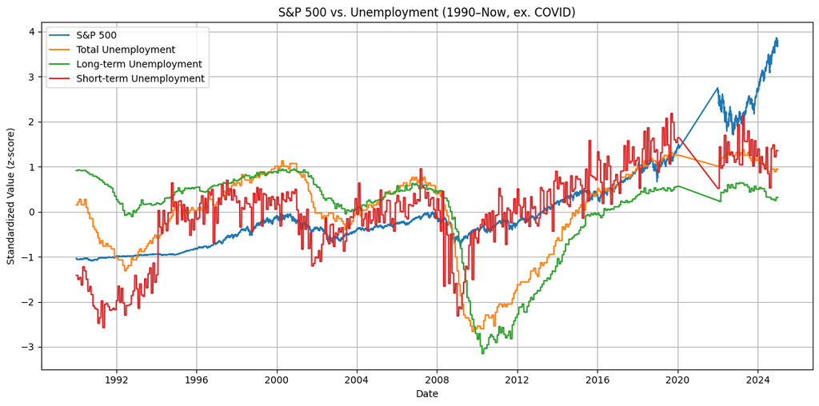

```python
#1990 to today
start_date = "1990-01-01"
end_date   = pd.Timestamp.today().strftime("%Y-%m-%d")

unemp = (
    df[['Unemployment Rate']]
      .loc[start_date:end_date]
      .reset_index()
);
# Long‑term unemployment (27+ weeks)
uemp27 = (
    df[['Unemployed ≥ 27 Weeks']]
      .loc[start_date:end_date]
      .reset_index()
)
# Short‑term unemployment (<5 weeks)
uemplt5 = (
    df[['Unemployed 5 Weeks or Less']]
      .loc[start_date:end_date]
      .reset_index()
)
# Combine all three into one table
unemp_all = (
    unemp
    .merge(uemp27, on='Date', how='outer')
    .merge(uemplt5, on='Date', how='outer')
    .sort_values('Date')
)

#Merge all the data and have it start at earlier data
merged = pd.merge_asof(
    tidy_sp500df,
    unemp_all,
    on="Date",
    direction="backward"
).dropna()


#Removes COVID from data
covid_start = pd.to_datetime("2020-02-01")
covid_end   = pd.to_datetime("2021-12-31")
mask = (merged["Date"] >= covid_start) & (merged["Date"] <= covid_end)
merged = merged.loc[~mask].copy()


# Standardize all the data
for col in ["SP500_Close_Price", "Unemployment Rate", "Unemployed ≥ 27 Weeks", "Unemployed 5 Weeks or Less"]:
    merged[col] = (merged[col] - merged[col].mean()) / merged[col].std()

# Invert unemployment series to align with S&P
for col in ["Unemployment Rate", "Unemployed ≥ 27 Weeks", "Unemployed 5 Weeks or Less"]:
    merged[col] = -merged[col]


plt.figure(figsize=(12, 6))
plt.plot(merged["Date"], merged["SP500_Close_Price"], label="S&P 500")
plt.plot(merged["Date"], merged["Unemployment Rate"],        label="Total Unemployment")
plt.plot(merged["Date"], merged["Unemployed ≥ 27 Weeks"],    label="Long-term Unemployment")
plt.plot(merged["Date"], merged["Unemployed 5 Weeks or Less"],     label="Short-term Unemployment")

plt.xlabel("Date")
plt.ylabel("Standardized Value (z-score)")
plt.title("S&P 500 vs. Unemployment (1990–Now, ex. COVID)")
plt.legend()
plt.grid(True)
plt.tight_layout()
plt.show()
```

We can see that all the unemployment rates follow a similar curve, which makes sense because when unemployment rates are bad, it is clear that the stock market and overall economy would suffer. By using three different metrics of unemployment we can obtain multiple conclusions.

Firsty, how the long term unemployment line mirrors the S&P500 line except being pushed further on moments of decline and growth. Additionally the line is curved which can be a good indicator of recessions and times of growth. This is because it takes unemployment more time to smooth out, and is delayed from rises and declines of the overall market. It can create a good estimate on whether the market is going to stay in a decline or reach expansion.

Secondly, short term unemployment also follows the S&P500, except it is very jagged and constantly switches from above and below the market line. While it would be a bad indicator of long-term growth, the quick drops and rises usually come a month or two before the drops and rises of the market. This can be a good prediction of short term growth, and help decide when to invest.

# S&P500 and Economic Factors Correlation

By using the graph above we can confirm that economic indicators have at least some correlation to the S&P500. If we are looking to predict the price of the S&P500 a question we need to answer is which economic factors are most correlated with the market. Because there would be no point to predict market movement using a variable that has no correlation with it.

```python
pct = df.pct_change()

#  Calculate correlation of each series’ % change with S&P 500
#    The Fred has a column "S&P 500" representing monthly changes
results = {}
for econ_factor in mapping.values():
    if econ_factor in pct.columns and 'S&P 500' in df.columns:
        results[econ_factor] = pct[econ_factor].corr(df['S&P 500'])

corr_df = pd.DataFrame.from_dict(
    results, orient='index', columns=['Corr_with_SP500']
).sort_values('Corr_with_SP500', ascending=False)

# Display the correlations
print(corr_df)
```

```
                                Corr_with_SP500
Effective Federal Funds Rate           0.133577
Trade-Weighted USD Index               0.055220
M1 Money Stock                         0.054598
Unemployed 5 Weeks or Less             0.034072
Initial Unemployment Claims            0.030492
Unemployment Rate                      0.004069
Housing Permits (SAAR)                -0.001668
PPI: Finished Goods                   -0.003500
Avg Weekly Overtime Hours: Mfg        -0.017793
Real Personal Consumption Exp.        -0.019811
Real Personal Income                  -0.024624
Unemployed ≥ 27 Weeks                 -0.029277
IP: Consumer Goods                    -0.064776
Industrial Production Index           -0.065919
Total Business Inventories            -0.119401
CPI: All Items                        -0.120128
```

As we can see each factor has a different correlation from the market. However this takes data since 1960, and as seen in the unemployment line chart, even since 1990 the unemployment rate went above and below the market many times. Starting from 1960 can bring in irrelevant data, due to time periods such as wars and COVID that should not be used if making a prediction model. The code below shows the same code, but only taking the 90s which was a good decade for the market, and we can really see how much the S&P500 is correlated with these values.

```python
start, end = "1990-01-01", "2000-12-31"


pct = pct.loc[start:end]

sp500 = df.loc[start:end, 'S&P 500']

results = {}
for econ_factor in mapping.values():
    if econ_factor in pct.columns:
        # use the sliced sp500 instead of df['S&P 500']
        results[econ_factor] = pct[econ_factor].corr(sp500)

corr_df = pd.DataFrame.from_dict(
    results, orient='index', columns=['Corr_with_SP500']
).sort_values('Corr_with_SP500', ascending=False)

print(corr_df)
```

```
                                Corr_with_SP500
Real Personal Consumption Exp.         0.242236
Effective Federal Funds Rate           0.179285
Total Business Inventories             0.154450
Real Personal Income                   0.141639
Trade-Weighted USD Index               0.136363
Industrial Production Index            0.080471
PPI: Finished Goods                    0.037999
Initial Unemployment Claims            0.020303
IP: Consumer Goods                     0.009788
Unemployed 5 Weeks or Less             0.009365
Housing Permits (SAAR)                 0.006392
Unemployment Rate                     -0.123627
Avg Weekly Overtime Hours: Mfg        -0.146954
CPI: All Items                        -0.180310
Unemployed ≥ 27 Weeks                 -0.185892
M1 Money Stock                        -0.383391
```

By using a clear time period we can now tell how much more correlation there is between these factors and the S&P500. By using this data we can get clear information about which of these are the best indicators to predict market movement. Some observations I could make from this table:

- Real Personal Consumption Expenditure has highest correlation. This makes sense because in the months where consumption accelerates, more spending is done, making businesses and the market in general rise as well.
- Housing pertmits, short term unemployment and consumer goods production all have a correlation of almost 0, making them bad indicators of market movement and would be unnecessary to use in a prediction model.
- The M1 money stock has a strong negative correlation. This makes sense because as a simple definition the M1 measures liquidity and how much "ready to spend money" there is. When the stock market is doing well people often invest their on-hand money, however when the stock market is dropping people often hold onto more money and have it in places like their checking accounts.

# Industry ETF Sensitivity to Economic Factors

The S&P500 represents the whole market, however in situations it might be more valuable to look at specific industries. By using the same macroeconomic factors as before, we can take different industry ETFs and find the correlation each industry has to each factor.

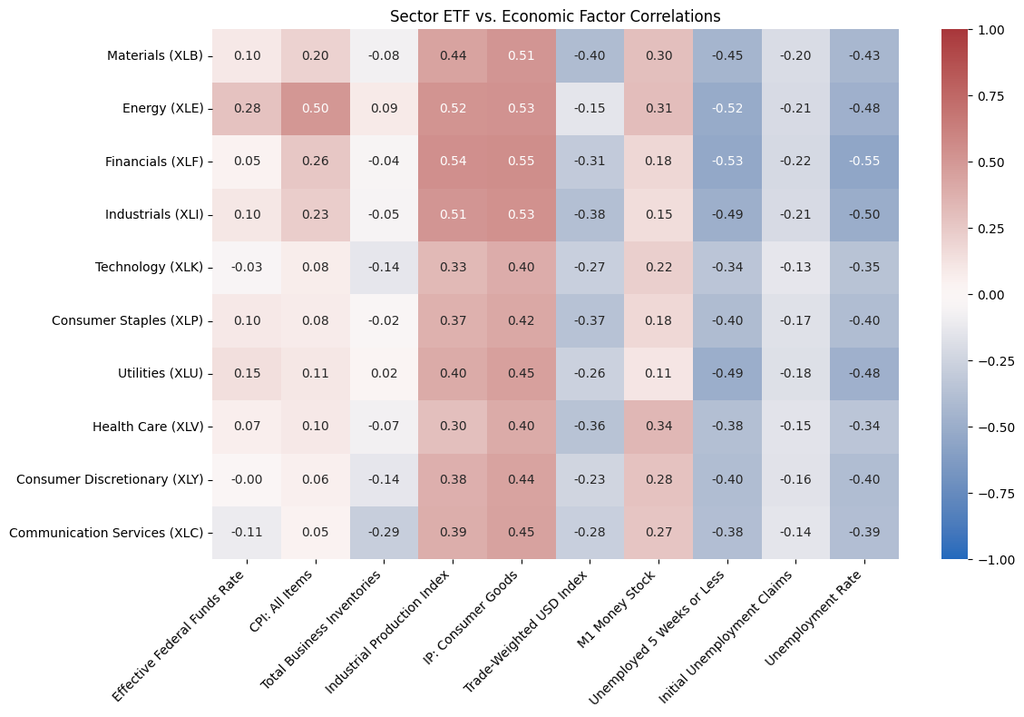

```python
# grab sector ETFs and rename
sectors = ['XLB','XLE','XLF','XLI','XLK','XLP','XLU','XLV','XLY','XLC']
sector_names = {
    'XLB': 'Materials (XLB)',
    'XLE': 'Energy (XLE)',
    'XLF': 'Financials (XLF)',
    'XLI': 'Industrials (XLI)',
    'XLK': 'Technology (XLK)',
    'XLP': 'Consumer Staples (XLP)',
    'XLU': 'Utilities (XLU)',
    'XLV': 'Health Care (XLV)',
    'XLY': 'Consumer Discretionary (XLY)',
    'XLC': 'Communication Services (XLC)'
}

# grab economic factors
factors = [
    'Effective Federal Funds Rate',
    'CPI: All Items',
    'Total Business Inventories',
    'Industrial Production Index',
    'IP: Consumer Goods',
    'Trade-Weighted USD Index',
    'M1 Money Stock',
    'Unemployed 5 Weeks or Less',
    'Initial Unemployment Claims',
    'Unemployment Rate'
]

# monthly % changes
factor_pct = df[factors].pct_change().dropna()

# grab start and end and resample
start_date = factor_pct.index.min().strftime('%Y-%m-%d')
end_date   = factor_pct.index.max().strftime('%Y-%m-%d')

#Get monthly percent change of etfs
sec_daily = yf.download(sectors, start=start_date, end=end_date, progress=False)['Close']
sec_monthly = sec_daily.resample('MS').first()
sec_pct     = sec_monthly.pct_change().dropna()

#Find correlation between factors and sectors
common = sec_pct.join(factor_pct, how='inner')
corr_matrix = common[sectors + factors].corr().loc[sectors, factors]

plt.figure(figsize=(12, 8))
sns.heatmap(
    corr_matrix,
    annot=True,         # draw the correlation value in each cell
    fmt=".2f",          # two decimal places
    cmap="vlag",        # color of map
    vmin=-1, vmax=1,    # color scale to -1 to +1
    xticklabels=factors,
    yticklabels=[sector_names[t] for t in sectors]
)

plt.xticks(rotation=45, ha='right')
plt.yticks(rotation=0)  # keep sector names horizontal

plt.title('Sector ETF vs. Economic Factor Correlations')
plt.tight_layout()
plt.show()
```

As seen above, we can tell that each industry has different levels of sensitivity to economic changes. An example of where this data could be important is if there are predicitions of economic changes, an investor could change their investing plans to different industries based on how affected they are. If there is a prediction of rising unemployment rates it might be a smart decision to invest in a technology company, which is less reactive to unemployment versus a company in the financial sector. Another interesting observation I saw was how Energy has by far the highest correlation with CPI. A simple explanation of this is that energy represent gas and oil, and CPI is a good representation of inflation. From this data we can tell that rises in inflation is driven by the same rises you may see in gas prices.

# FRED Industry Data

Above we looked at correlations between industry ETFs and macroeconomic changes. While industry ETFs represent a tradable financial product, the FRED offers more specific representations of industries. We can now pull things like retail and food services sale and industrial production, to see how the economy can affect specific parts of certain industries. In the code below we took 10 random industry movements and compared them to how they move with the economy.

```python
# Load fred data
fred = pd.read_csv("https://raw.githubusercontent.com/schaferkotter-freed/schaferkotter-freed.github.io/main/2025-03.csv")

# In the dataset the first row has the transformation the data went through
# a column with transformation 5, means it is the value in its log form
# drop the sasdate code, because it only contains the word "transform"
tcode_row = fred.iloc[0].drop('sasdate').astype(int)
#Create a dataframe in case we ever have to access the transformations of these values
transform_df = pd.DataFrame({
    'series': tcode_row.index,
    'tcode': tcode_row.values
})
#Remove this dataframe out of data
df = fred.iloc[1:].copy()

#Change date to get in correct form, and make it the index
df.rename(columns={'sasdate': 'date'}, inplace=True)
df['date'] = pd.to_datetime(df['date'], format='%m/%d/%Y')
df.set_index('date', inplace=True)

# Convert all remaining columns to numeric values
for col in df.columns:
    df[col] = pd.to_numeric(df[col], errors='coerce')

#Map all column names to make them their real names
mapping = {
    'RPI': 'Real Personal Income',
    'W875RX1': 'Real Personal Income ex Transfers',
    'DPCERA3M086SBEA': 'Real Personal Consumption Expenditures',
    'CMRMTSPLx': 'Real Manufacturing & Trade Industries Sales',
    'RETAILx': 'Retail & Food Services Sales',
    'INDPRO': 'Industrial Production Index',
    'IPFPNSS': 'IP: Final Products & Nonindustrial Supplies',
    'IPFINAL': 'IP: Final Products',
    'IPCONGD': 'IP: Consumer Goods',
    'IPDCONGD': 'IP: Durable Consumer Goods',
}
df.rename(columns=mapping, inplace=True)
```

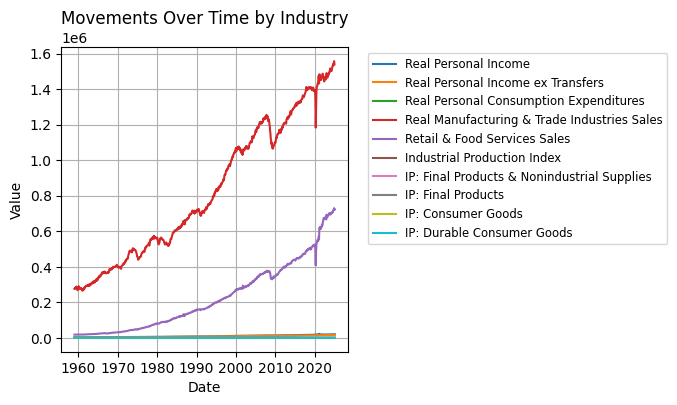

```python
mapped_columns = list(mapping.values())
df_mapped = df[mapped_columns]

plt.figure(figsize=(7, 4))

for col in df_mapped.columns:
    plt.plot(df_mapped.index, df_mapped[col], label=col)

plt.title("Movements Over Time by Industry")
plt.xlabel("Date")
plt.ylabel("Value")
plt.legend(loc='upper left', bbox_to_anchor=(1.05, 1), fontsize='small')
plt.tight_layout()
plt.grid(True)
plt.show()
```

We can see here the increase over time by industry. Though it's clear that manufacturing and sales is by far the frontrunner, retail and food services has increased as well. This makes sense that these variables have the biggest increase, because they represent dollar value of sales, which obviously increase over time as inflation and population grows, the overall economy flows more and makes more sales.

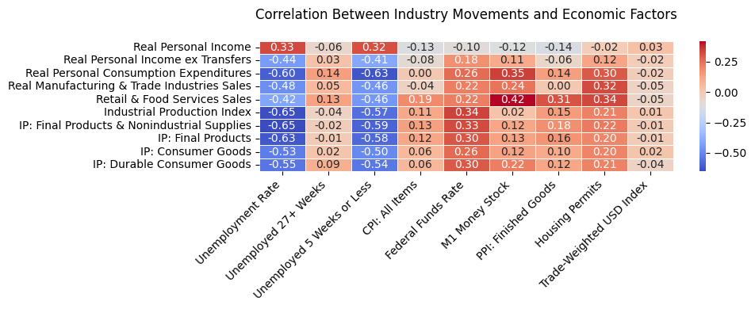

|  | Industry | Economic Factor | Absolute Correlation |
| --- | --- | --- | --- |
| 54 | IP: Final Products & Nonindustrial Supplies | Unemployment Rate | 0.652613 |
| 45 | Industrial Production Index | Unemployment Rate | 0.648250 |
| 20 | Real Personal Consumption Expenditures | Unemployed 5 Weeks or Less | 0.628481 |
| 63 | IP: Final Products | Unemployment Rate | 0.625912 |
| 18 | Real Personal Consumption Expenditures | Unemployment Rate | 0.603453 |

```python
newDf = fred.iloc[1:].copy() # new df with no manipulation

industry_mapping = { # mapping again so we can do it all in one go
    'RPI': 'Real Personal Income',
    'W875RX1': 'Real Personal Income ex Transfers',
    'DPCERA3M086SBEA': 'Real Personal Consumption Expenditures',
    'CMRMTSPLx': 'Real Manufacturing & Trade Industries Sales',
    'RETAILx': 'Retail & Food Services Sales',
    'INDPRO': 'Industrial Production Index',
    'IPFPNSS': 'IP: Final Products & Nonindustrial Supplies',
    'IPFINAL': 'IP: Final Products',
    'IPCONGD': 'IP: Consumer Goods',
    'IPDCONGD': 'IP: Durable Consumer Goods',
}

newDf.rename(columns=industry_mapping, inplace=True)

factor_mapping = { # various factors, since it would be a lot to analyze them all
    'UNRATE': 'Unemployment Rate',
    'UEMP27OV': 'Unemployed 27+ Weeks',
    'UEMPLT5': 'Unemployed 5 Weeks or Less',
    'CPIAUCSL': 'CPI: All Items',
    'FEDFUNDS': 'Federal Funds Rate',
    'M1SL': 'M1 Money Stock',
    'WPSFD49207': 'PPI: Finished Goods',
    'PERMIT': 'Housing Permits',
    'TWEXAFEGSMTHx': 'Trade-Weighted USD Index'
}

newDf.rename(columns=factor_mapping, inplace=True)

industry_cols = list(industry_mapping.values())
factor_cols = list(factor_mapping.values())

pct_changes = newDf[industry_cols + factor_cols].pct_change().dropna()

corr_matrix = pct_changes.corr()

industry_factor_corr = corr_matrix.loc[industry_cols, factor_cols]

# heatmap
plt.figure(figsize=(10, 4))
sns.heatmap(industry_factor_corr, annot=True, fmt=".2f", cmap='coolwarm', linewidths=0.5)
plt.title('Correlation Between Industry Movements and Economic Factors', pad=20)
plt.xticks(rotation=45, ha='right')
plt.yticks(rotation=0)
plt.tight_layout()
plt.show()

# table for better lookup
corr_pairs = []
for industry in industry_cols:
    for factor in factor_cols:
        corr = industry_factor_corr.loc[industry, factor]
        corr_pairs.append({
            'Industry': industry,
            'Economic Factor': factor,
            'Absolute Correlation': abs(corr)
        })

corr_df = pd.DataFrame(corr_pairs)
top_correlations = corr_df.sort_values('Absolute Correlation', ascending=False).head(20)
display(top_correlations.head())
```

Unsuprisingly, we can see that Unemployment Rate is a major economic factor across industries. This is even true for specific fields within unemployment rate, such as the "5 weeks or less" factor, as seen in the correlation for RPCE.

# Machine Learning Models

Our idea is to build a general S&P 500 forecasting model using a linear regression model that accounts for the key macroeconomic factors we have discovered throughout this project to see how well the broader economy alone can explain stock movements. We align each series to monthly S&P 500 closes, split the data into training and validation sets, and use a pipeline (vectorization, standard scaling, linear regression) with a 4 fold cross-validation to assess performance. Additionally we have picked a specific time frame so our model is not skewed with very old data. Our main challenge is that markets respond to many non-economic factors as well, so perfect accuracy is unlikely but this framework lets us quantify how strong the relationship is.

```python
#1980 to 2010
start_date = "1990-01-01"
end_date   = "2010-01-01"

#Combines the 5 economic factors with the most correlation
econ_all = (
    df[top5_factors]
    .loc[start_date:end_date]
    .reset_index()
    .sort_values('Date')
)

#FRED has specific days of the month so need to merge based on the one entry each dataset shares per month

# 1) turn Date into index and grab month-end closes
sp500_monthly = (
    tidy_sp500df
      .set_index('Date')['SP500_Close_Price']
      .resample('ME')     # month‐end frequency
      .last()            # take last trading‐day close
      .to_frame()
      .reset_index()
)

# 2) now econ_all is already monthly (Date at month‐end or month‐start)
#    might want to align it to month‐end as well:
econ_monthly = econ_all.copy()
econ_monthly['Date'] = econ_monthly['Date'].dt.to_period('M').dt.to_timestamp('M')

# 3) simple merge on the identical Date
merged_monthly = pd.merge(
    sp500_monthly,
    econ_monthly,
    on='Date',
    how='inner'
)

features = ["CPI: All Items", "Unemployed ≥ 27 Weeks", "Real Personal Consumption Exp.", "Effective Federal Funds Rate", "M1 Money Stock"]
y = merged_monthly["SP500_Close_Price"].values
X_dicts = merged_monthly[features].to_dict(orient="records")

# 1) Split into train/validation (no shuffle so time order is preserved)
X_train_dicts, X_val_dicts, y_train, y_val = train_test_split(
    X_dicts, y, test_size=0.4, shuffle=False
)

# 2) Vectorize
vec = DictVectorizer(sparse=False)
scaler = StandardScaler()
model = LinearRegression()
pipeline = Pipeline([("vectorizer", vec), ("scaler", scaler), ("fit", model)])

cv_results = cross_validate(pipeline, X_train_dicts, y_train, cv=4,
                                scoring='neg_mean_absolute_error',
                                return_train_score=True)

pipeline.fit(X_train_dicts, y_train)
avg_train_mae = -np.mean(cv_results['train_score'])
avg_val_mae = -np.mean(cv_results['test_score'])
print(avg_train_mae, avg_val_mae)
```

[output not shown]

In order to see how well it can actually predict a price we will take a month out of our dataset. We will provide the model the real economic data at the time, and see if it can predict an accurate price.

```python
test_row = df.iloc[615]
print(test_row)
test_var = test_row[features].to_dict()
predicted_sp500 = pipeline.predict([test_var])[0]
row = tidy_sp500[tidy_sp500["Date"] == "2010-03-30"]
print("Real value:", row["SP500_Close_Price"].iloc[0])
print("Predicted value:", predicted_sp500)
```

[output not shown]

# Conclusion

Although our analysis confirms that S&P 500 prices and macroeconomic indicators move together to some degree, it’s clear that a prediction model built solely on those factors is not viable. These indicators are only one piece of a more complex picture where even when we project two months beyond our training window, the model’s price estimates are wildly inaccurate.

That being said, this project still offers real value. With industry‐specific correlation data, one could develop a risk‐assessment tool that simulates portfolio performance under various macroeconomic scenarios. Alternatively, a more broad classification model could increase the accuracy, flagging whether incoming economic signals are likely to bring a recession or an inflationary period.

Overall, this project deepened our understanding of how economics and the stock market interact. We gained experience extracting and analyzing large public data sets, uncovered observations we had never considered, and, most importantly, learned firsthand why the stock market remains so notoriously difficult to forecast.

```python
from google.colab import drive
drive.mount('/content/drive')
```

```python
!pip install nbconvert  # Install nbconvert
!pip install --upgrade jinja2

# Ensure file exists and the path is correct
!ls /content/drive/MyDrive/Colab\ Notebooks/FinalTutorial.ipynb

# Convert the notebook
!jupyter nbconvert --to html "/content/drive/MyDrive/Colab Notebooks/FinalTutorial.ipynb" # Run with correct path
```